# Factorial_Design_Calvin_Tran

An experiment was conducted to study life (in hours) of two different brands of batteries in three different devices (radio, camera, and portable DVD player). A completely randomized two-factor factorial experiment was conducted and the following data resulted.

```r
library(ggplot2)

#read the data
Batteries_Life = read.csv('/content/Batteries_Life.csv')
Batteries_Life$Brand = as.factor(Batteries_Life$Brand)
Batteries_Life$Device = as.factor(Batteries_Life$Device)
print(dim(Batteries_Life))
head(Batteries_Life)
```

```
[1] 12  3
```

A data.frame: 6 × 3

|  | Brand <fct> | Device <fct> | Life <dbl> |
| --- | --- | --- | --- |
| 1 | A | Radio | 8.6 |
| 2 | A | Radio | 8.2 |
| 3 | A | Camera | 7.9 |
| 4 | A | Camera | 8.4 |
| 5 | A | DVD_Player | 5.4 |
| 6 | A | DVD_Player | 5.7 |

# Analysis of Variance and test hypotheses on main effects

Using significance level=0.05

```r
Batteries_Life_aov = aov(Life~Brand+Device, Batteries_Life)
summary(Batteries_Life_aov)
```

```
            Df Sum Sq Mean Sq F value  Pr(>F)
Brand        1  0.801   0.801   10.74  0.0112 *
Device       2 22.445  11.222  150.47 4.5e-07 ***
Residuals    8  0.597   0.075
---
Signif. codes:  0 ‘***’ 0.001 ‘**’ 0.01 ‘*’ 0.05 ‘.’ 0.1 ‘ ’ 1
```

The p-values for each main effect are below the significance level of 0.05.

Conclusion: The main effects contribute to a difference in battery life.

### F-statistic for main effects

2x3 design with 12 examples

12/6 = 2 replicates = n

```
# a=2
# b=3
# n=2
```

df for main effect of a = (a-1)

```
# (2-1) = 1
```

df for main effect of b = (b-1)

```
# (3-1) = 2
```

df for error (ab[n-1])

```
# (3*2)*(2-1) = 6
```

```r
qf(c(0.05),1,6,lower.tail=FALSE)
qf(c(0.05),2,6,lower.tail=FALSE)
```

5.9873776072737

5.14325284978472

## Analysis of Main Effects

The p-values for each factor are **lower** than the significance level of 0.05.

The F values are **higher** than the critical value of F.

- 10.74 & 150.47 > 5
- This indicates a difference between the means.

Since a significant difference in means is found, we want to know what the effect is. Use multiple comparisons.

```r
# Multiple comparisons for main effects
install.packages('emmeans')
library(emmeans)
```

```r
print(emmeans(Batteries_Life_aov, pairwise ~ Brand | Device))
```

```
$emmeans
Device = Camera:
 Brand emmean    SE df lower.CL upper.CL
 A       8.17 0.158  8     7.80     8.53
 B       8.68 0.158  8     8.32     9.05

Device = DVD_Player:
 Brand emmean    SE df lower.CL upper.CL
 A       5.44 0.158  8     5.08     5.81
 B       5.96 0.158  8     5.59     6.32

Device = Radio:
 Brand emmean    SE df lower.CL upper.CL
 A       8.49 0.158  8     8.13     8.86
 B       9.01 0.158  8     8.64     9.37

Confidence level used: 0.95

$contrasts
Device = Camera:
 contrast estimate    SE df t.ratio p.value
 A - B      -0.517 0.158  8  -3.277  0.0112

Device = DVD_Player:
 contrast estimate    SE df t.ratio p.value
 A - B      -0.517 0.158  8  -3.277  0.0112

Device = Radio:
 contrast estimate    SE df t.ratio p.value
 A - B      -0.517 0.158  8  -3.277  0.0112
```

These results indicate **the mean battery life is smaller for brand A than it is for brand B**, for all three tested device types.

```r
print(emmeans(Batteries_Life_aov, pairwise ~ Device | Brand))
```

```
$emmeans
Brand = A:
 Device     emmean    SE df lower.CL upper.CL
 Camera       8.17 0.158  8     7.80     8.53
 DVD_Player   5.44 0.158  8     5.08     5.81
 Radio        8.49 0.158  8     8.13     8.86

Brand = B:
 Device     emmean    SE df lower.CL upper.CL
 Camera       8.68 0.158  8     8.32     9.05
 DVD_Player   5.96 0.158  8     5.59     6.32
 Radio        9.01 0.158  8     8.64     9.37

Confidence level used: 0.95

$contrasts
Brand = A:
 contrast            estimate    SE df t.ratio p.value
 Camera - DVD_Player    2.725 0.193  8  14.111  <.0001
 Camera - Radio        -0.325 0.193  8  -1.683  0.2691
 DVD_Player - Radio    -3.050 0.193  8 -15.794  <.0001

Brand = B:
 contrast            estimate    SE df t.ratio p.value
 Camera - DVD_Player    2.725 0.193  8  14.111  <.0001
 Camera - Radio        -0.325 0.193  8  -1.683  0.2691
 DVD_Player - Radio    -3.050 0.193  8 -15.794  <.0001

P value adjustment: tukey method for comparing a family of 3 estimates
```

These results indicate that battery life for device types **camera and radio have no significant difference**, yet the **DVD player device has a lower mean than the other two**.

This is obtained from the sigificant p-values and the comparison estimates:

- Camera - DVD_player = 2.725
- DVD_player - Radio = -3.050 --> reverse the order = 3.050

## Results of Main effects

Using the estimated difference in means and 95% confidence level:

- Brand A has a lower mean battery life than brand B
- DVD player has a lower mean battery life than camera & radio, which have equal mean battery lives to each other.
- The effect of the device type has a larger effect on the mean battery life than the brand of battery, based on the magnitude of the estimated difference.

# Analysis of Interaction effects

## Interaction Plot

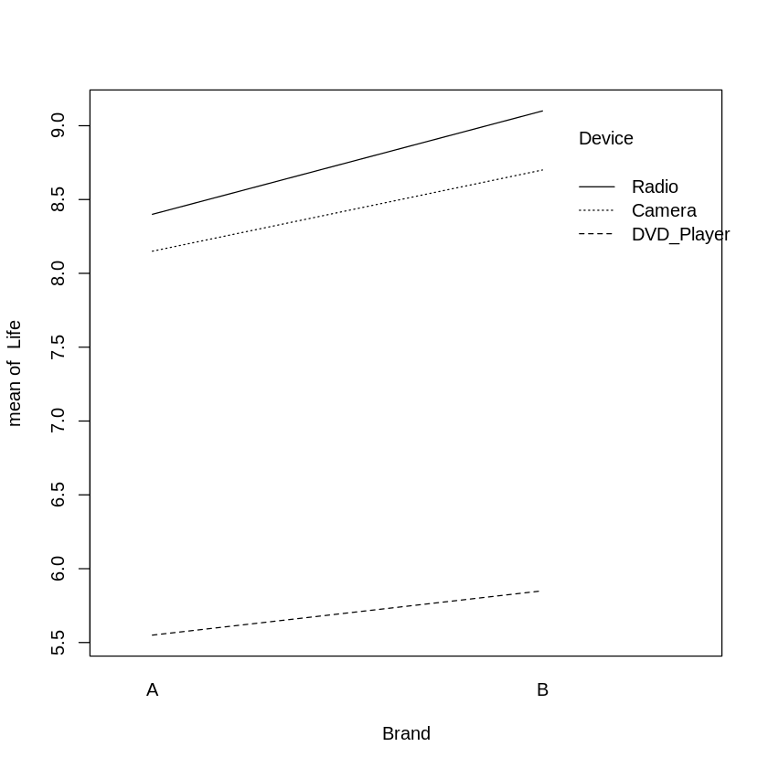

```r
#with(data-frame, R expression)
with(Batteries_Life, interaction.plot(Brand,Device,Life))
```

These lines are not completely parallel, but they are quite close to parallel. This suggests minimal interaction or no interaction between the two factors.

## Test interaction between factors

Using significance level=0.05

```r
Batteries_Interaction_aov = aov(Life~Brand*Device, Batteries_Life)
summary(Batteries_Interaction_aov)
```

```
             Df Sum Sq Mean Sq F value   Pr(>F)
Brand         1  0.801   0.801   9.330   0.0224 *
Device        2 22.445  11.222 130.748 1.13e-05 ***
Brand:Device  2  0.082   0.041   0.476   0.6430
Residuals     6  0.515   0.086
---
Signif. codes:  0 ‘***’ 0.001 ‘**’ 0.01 ‘*’ 0.05 ‘.’ 0.1 ‘ ’ 1
```

### F-statistic for Interaction Effects

2x3 design with 12 examples

12/6 = 2 replicates = n

```
# a=3
# b=2
# n=2
```

df for interaction = (a-1)(b-1)

```
# (3-1)(2-1) = 2
```

df for error (ab[n-1])

```
# (3*2)*(2-1) = 6
```

```r
qf(c(0.05),2,6,lower.tail=FALSE)
```

5.14325284978472

## Interaction Results

Obtained p-value is 0.6430, while significance level is 0.05

- The p-value is **higher** than the significance level. In this case we accept the null hypothesis that no interaction occurs between the factors.

- the F-value is **lower** than the critical value. This indicates that a no difference exists betweens the two means.

Both the p-value and F-value indicate no interaction between the two factors.

# Model adequacy evaluation via Residual analysis

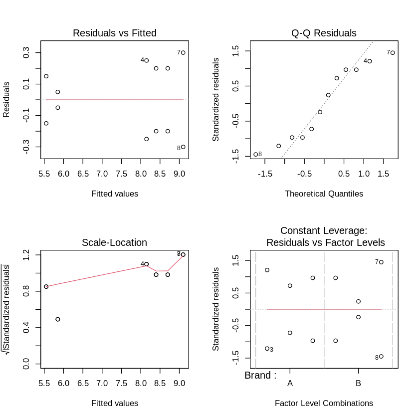

```r
par(mfrow=c(2,2))
plot(aov(Life~Brand*Device, Batteries_Life))
```

```r
#View outlier points
Batteries_Life[7:8,]
```

[output not shown]

Certain extreme residuals on the normal QQ plot stand out but otherwise look fine.

These outliers correspond to brand B in the radio device.

The scale location plot is not flat and indicates that the variances are unequal. This can be further explored by plotting the residuals against each of the factors.

### Plot Residuals against each factor level

```r
#append the residuals of the ANOVA analysis to the dataframe
Batteries_Life$residual = Batteries_Life_aov$residuals
head(Batteries_Life)
```

A data.frame: 6 × 4

|  | Brand <fct> | Device <fct> | Life <dbl> | residual <dbl> |
| --- | --- | --- | --- | --- |
| 1 | A | Radio | 8.6 | 0.10833333 |
| 2 | A | Radio | 8.2 | -0.29166667 |
| 3 | A | Camera | 7.9 | -0.26666667 |
| 4 | A | Camera | 8.4 | 0.23333333 |
| 5 | A | DVD_Player | 5.4 | -0.04166667 |
| 6 | A | DVD_Player | 5.7 | 0.25833333 |

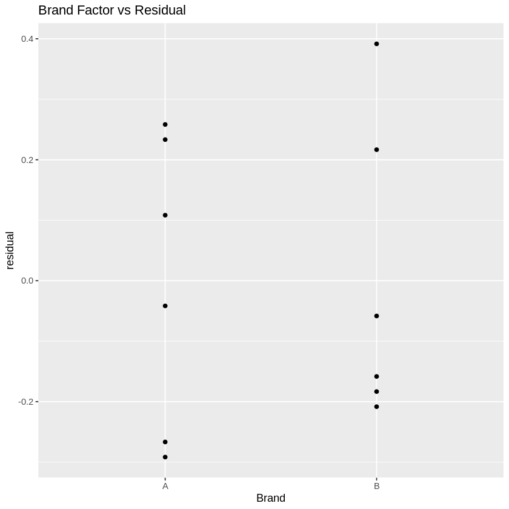

```r
#plot Brand factor vs Residual
ggplot(data=Batteries_Life, aes(x=Brand,y=residual))+
   geom_point()+
   labs(title='Brand Factor vs Residual')
```

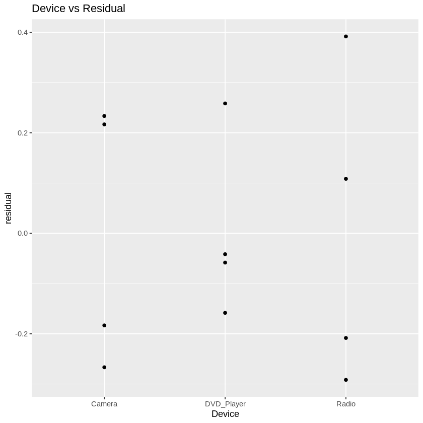

```r
#plot Device type vs Residual
ggplot(Batteries_Life, aes(x = Device, y = residual)) +
  geom_point()+
  labs(title='Device vs Residual')
```

The variance for Brand looks equal, but for Device types the variance for radio is larger than the other two device types, indicating an inequality of variance also seen on the Scale-Location plot above.

## Recommendation

Battery B lasts longer than battery A. This difference is about half an hour.

This is consistent for all three device types, ie. there is no device where battery A performs better. This is supported by a lack of interaction effects.